# Analysis on Red Wines Quality by LINA TA

> We are going to analyse a sample of red wines through their chemical properties and see which chemical properties determined their quality.

# Data dimension and table head

```
## [1] 1599   13
```

```
##   X fixed.acidity volatile.acidity citric.acid residual.sugar chlorides
## 1 1           7.4             0.70        0.00            1.9     0.076
## 2 2           7.8             0.88        0.00            2.6     0.098
## 3 3           7.8             0.76        0.04            2.3     0.092
## 4 4          11.2             0.28        0.56            1.9     0.075
## 5 5           7.4             0.70        0.00            1.9     0.076
## 6 6           7.4             0.66        0.00            1.8     0.075
##   free.sulfur.dioxide total.sulfur.dioxide density   pH sulphates alcohol
## 1                  11                   34  0.9978 3.51      0.56     9.4
## 2                  25                   67  0.9968 3.20      0.68     9.8
## 3                  15                   54  0.9970 3.26      0.65     9.8
## 4                  17                   60  0.9980 3.16      0.58     9.8
## 5                  11                   34  0.9978 3.51      0.56     9.4
## 6                  13                   40  0.9978 3.51      0.56     9.4
##   quality
## 1       5
## 2       5
## 3       5
## 4       6
## 5       5
## 6       5
```

# Data structure

```
## 'data.frame':    1599 obs. of  13 variables:
##  $ X                   : int  1 2 3 4 5 6 7 8 9 10 ...
##  $ fixed.acidity       : num  7.4 7.8 7.8 11.2 7.4 7.4 7.9 7.3 7.8 7.5 ...
##  $ volatile.acidity    : num  0.7 0.88 0.76 0.28 0.7 0.66 0.6 0.65 0.58 0.5 ...
##  $ citric.acid         : num  0 0 0.04 0.56 0 0 0.06 0 0.02 0.36 ...
##  $ residual.sugar      : num  1.9 2.6 2.3 1.9 1.9 1.8 1.6 1.2 2 6.1 ...
##  $ chlorides           : num  0.076 0.098 0.092 0.075 0.076 0.075 0.069 0.065 0.073 0.071 ...
##  $ free.sulfur.dioxide : num  11 25 15 17 11 13 15 15 9 17 ...
##  $ total.sulfur.dioxide: num  34 67 54 60 34 40 59 21 18 102 ...
##  $ density             : num  0.998 0.997 0.997 0.998 0.998 ...
##  $ pH                  : num  3.51 3.2 3.26 3.16 3.51 3.51 3.3 3.39 3.36 3.35 ...
##  $ sulphates           : num  0.56 0.68 0.65 0.58 0.56 0.56 0.46 0.47 0.57 0.8 ...
##  $ alcohol             : num  9.4 9.8 9.8 9.8 9.4 9.4 9.4 10 9.5 10.5 ...
##  $ quality             : int  5 5 5 6 5 5 5 7 7 5 ...
```

# Is there any missing values ?

```
## [1] 0
```

> The dataset contains 1599 different red wines analysed through 12 differents characteristics including their quality, type of acidity, density, ph, alcohol. There is no missing value.

# Analysis through different characteristics of the dataset

# Quality

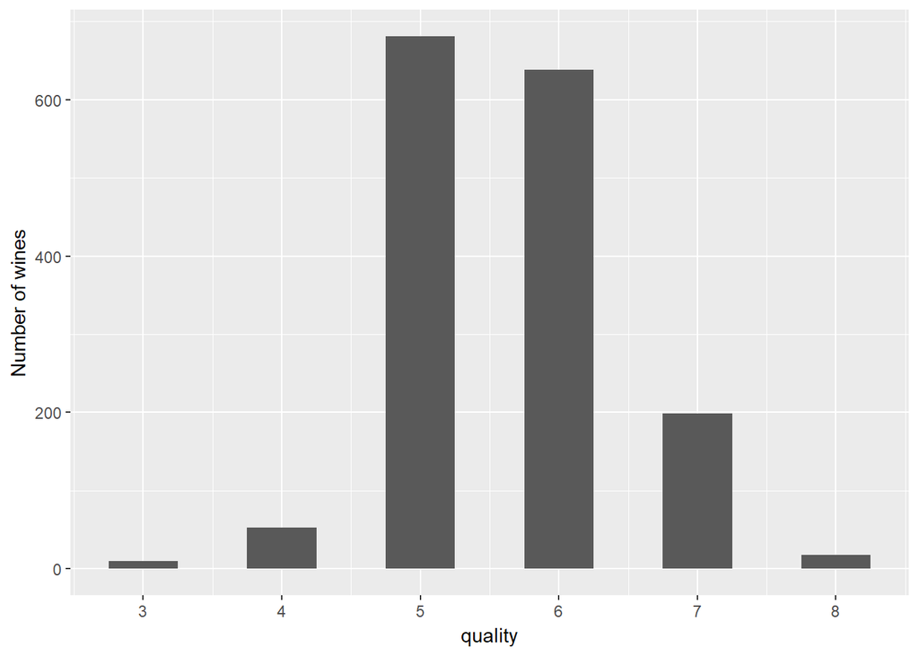

```
##    Min. 1st Qu.  Median    Mean 3rd Qu.    Max.
##   3.000   5.000   6.000   5.636   6.000   8.000
```

# Fixed acidity

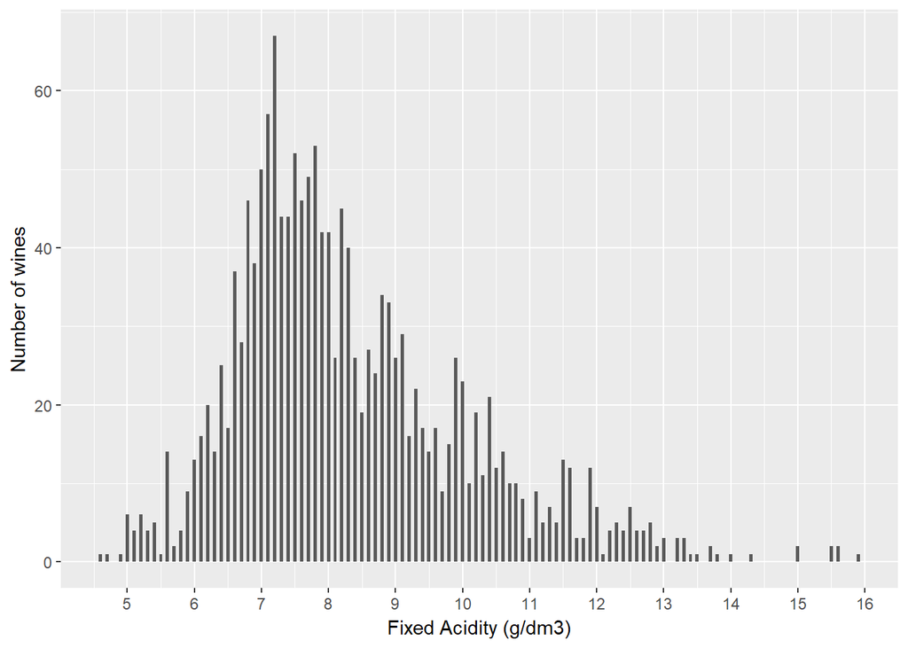

```
##    Min. 1st Qu.  Median    Mean 3rd Qu.    Max.
##    4.60    7.10    7.90    8.32    9.20   15.90
```

> The mean of fixed acidity level of the data sample is at 8.32g/dm3 The lowest fixed acidity at 4.6g/dm^3 while the highest is at 15.90g/dm3 The distribution appears to be skewed to the right

# Volatile acidity

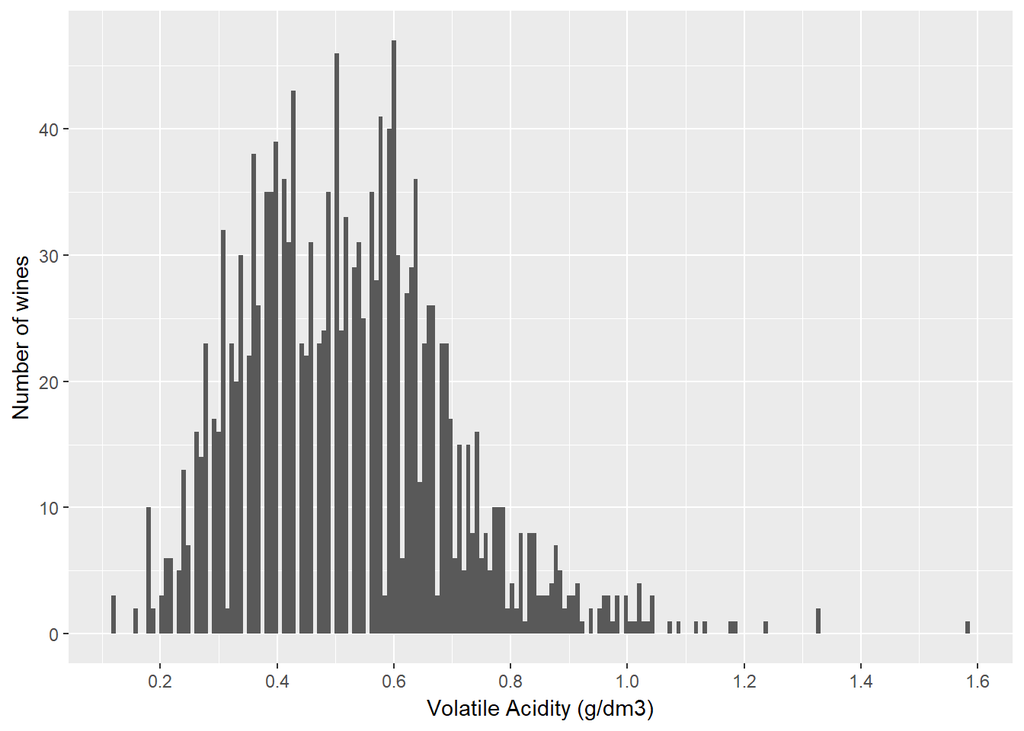

```
##    Min. 1st Qu.  Median    Mean 3rd Qu.    Max.
##  0.1200  0.3900  0.5200  0.5278  0.6400  1.5800
```

> The mean of volatile acidity level of the data sample is at 0.5278g/dm3 We notice that some wines have quite high volatile acidity up to 1.6g/dm3 which is over U.S legal limit for volatile acidity in red wine at 1.2g/dm3 and the taste of these wines might be closed to vinegar. The distribution appears to be lightly skewed to the right

# Citric Acid

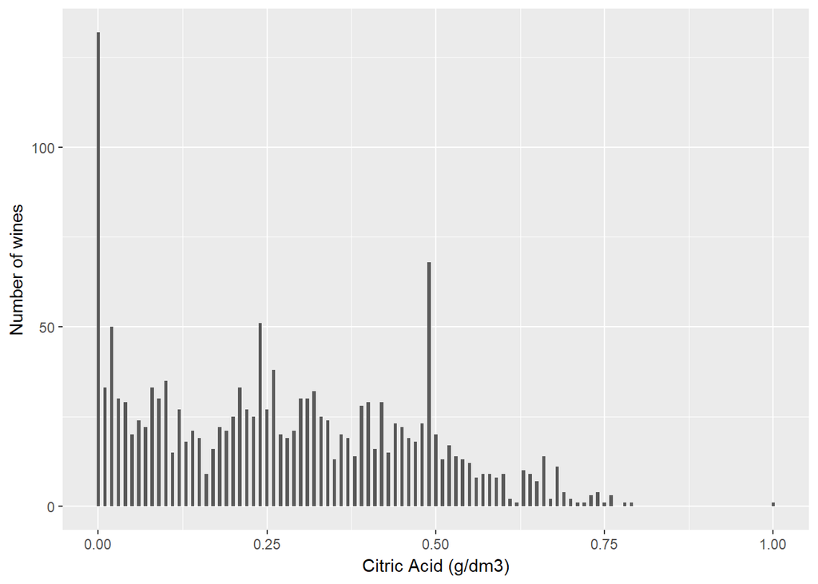

```
##    Min. 1st Qu.  Median    Mean 3rd Qu.    Max.
##   0.000   0.090   0.260   0.271   0.420   1.000
```

> Citric acid is added in wines to acifify the wine when it is too basic It is interesting to see that the graph contain some pics at around 0, 0.25, 0.5g/dm3 This might be intentional as there might be some standard on level of citric acid that can be added to the wine.

> The mean is at 0.271g/dm3 The lowest level at 0g/dm3 while the highest is at 1g/dm^3 The distribution appears to be skewed to the right

# Residual sugar

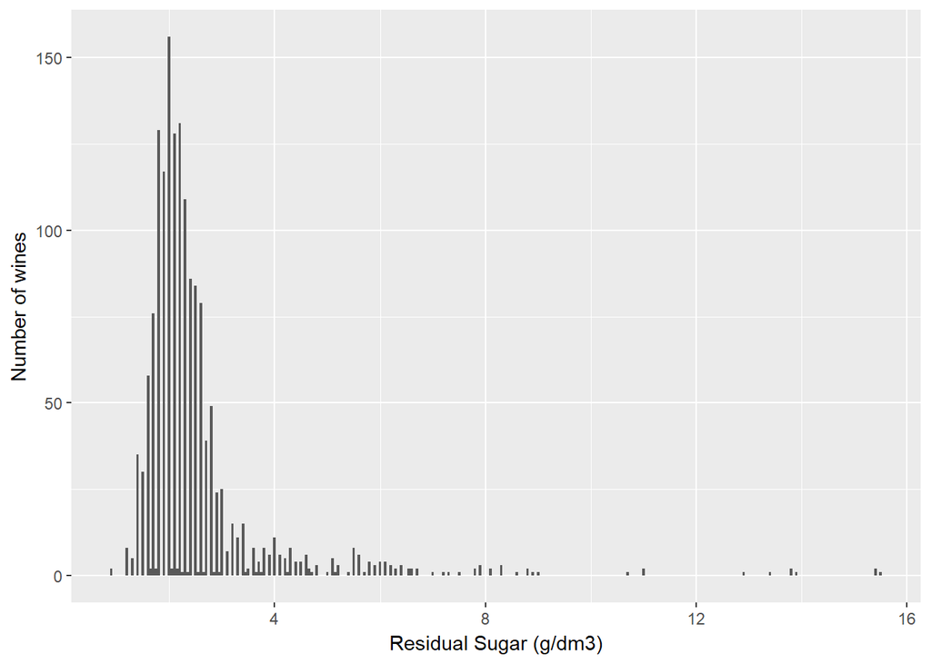

```
##    Min. 1st Qu.  Median    Mean 3rd Qu.    Max.
##   0.900   1.900   2.200   2.539   2.600  15.500
```

> The mean of residual sugar of the data sample is at 2.539g/dm3 with the 1st quartile and 3rd quartile between 1.9-2.6, which means that our wines sample are rather dry wines. The highest level of residual sugar is 15.5g/dm3 The distribution appears to be skewed to the right

# Chlorides

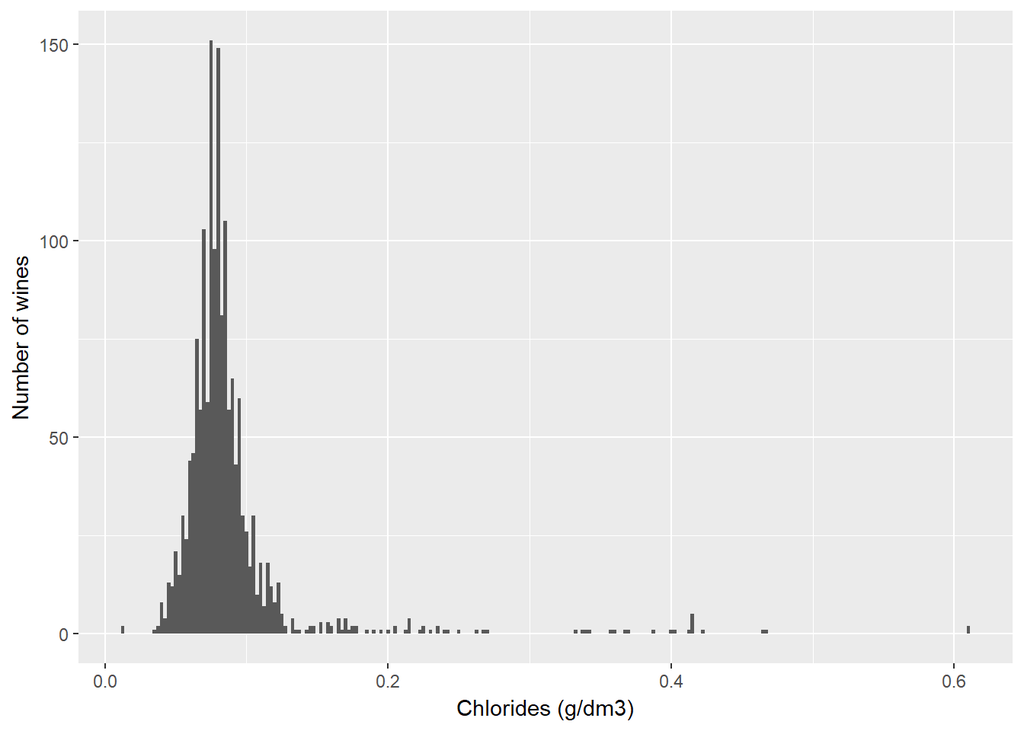

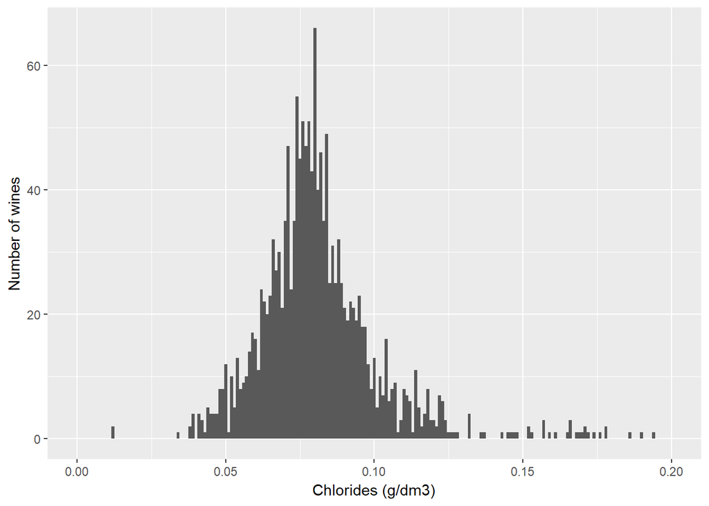

```
##    Min. 1st Qu.  Median    Mean 3rd Qu.    Max.
## 0.01200 0.07000 0.07900 0.08747 0.09000 0.61100
```

> The chlorides test the saltiness of the wines. We can see that the level of the chlorides is relatively low with a mean at 0.08747g/dm3. But we see also some outliers with level of chlorides up to 0.61100 g/dm3. The distribution is skewed to the right.

# Free sulfur dioxide

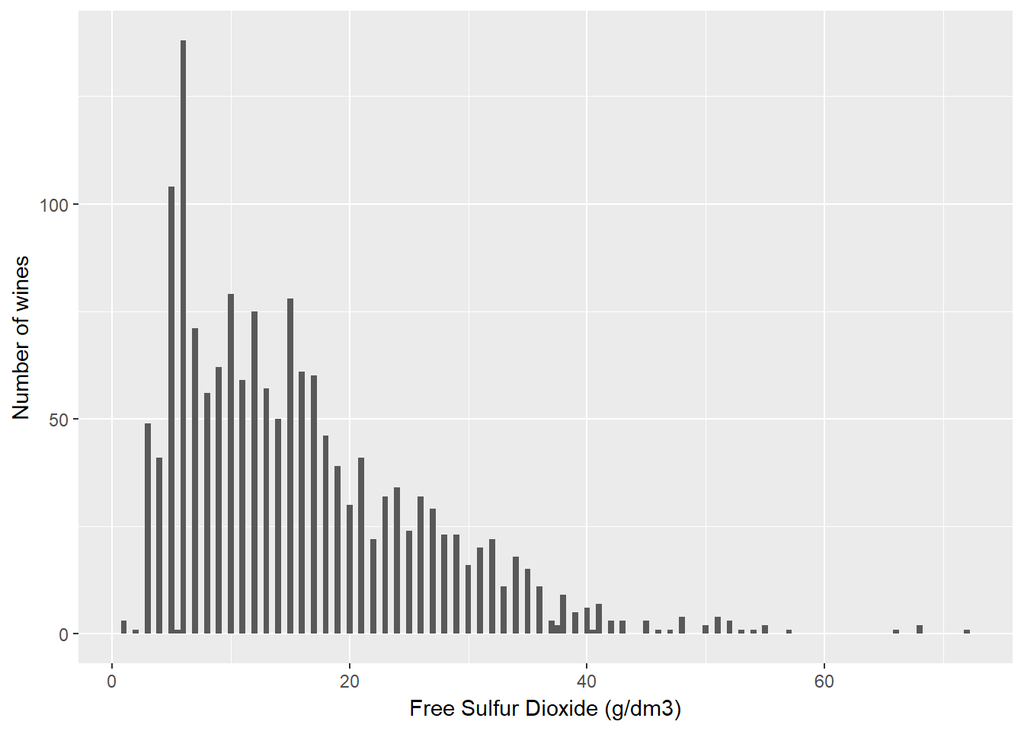

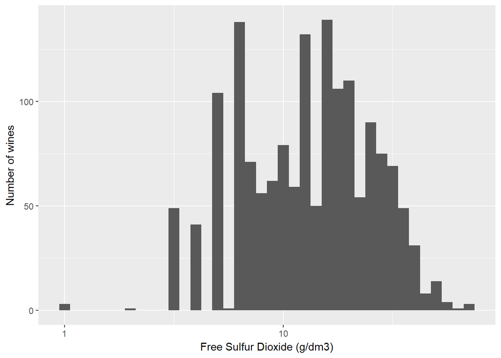

```
##    Min. 1st Qu.  Median    Mean 3rd Qu.    Max.
##    1.00    7.00   14.00   15.87   21.00   72.00
```

> The mean of free sulfur dioxide is at 15.87mg/dm^3 which act as a anti-microbial and anti-oxydant in the wine. The range stands from 1mg/dm^3 to 72mg/dm^3, which is quite high because it can give a special taste to the wine. The distribution is skewed to the right

# Total sulfur dioxide

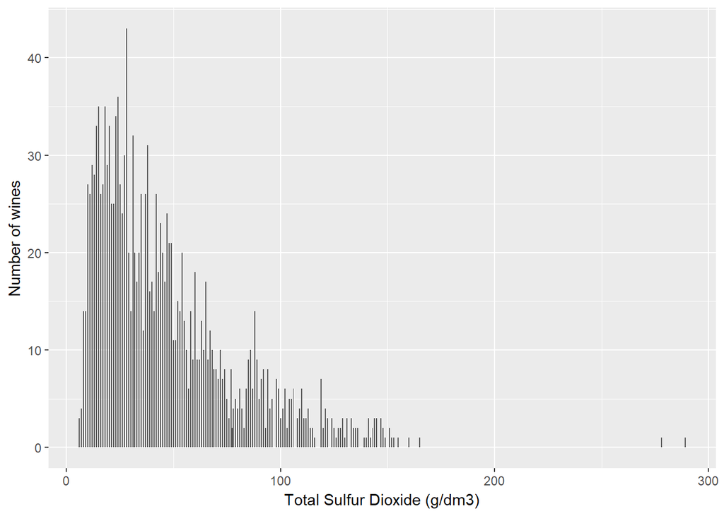

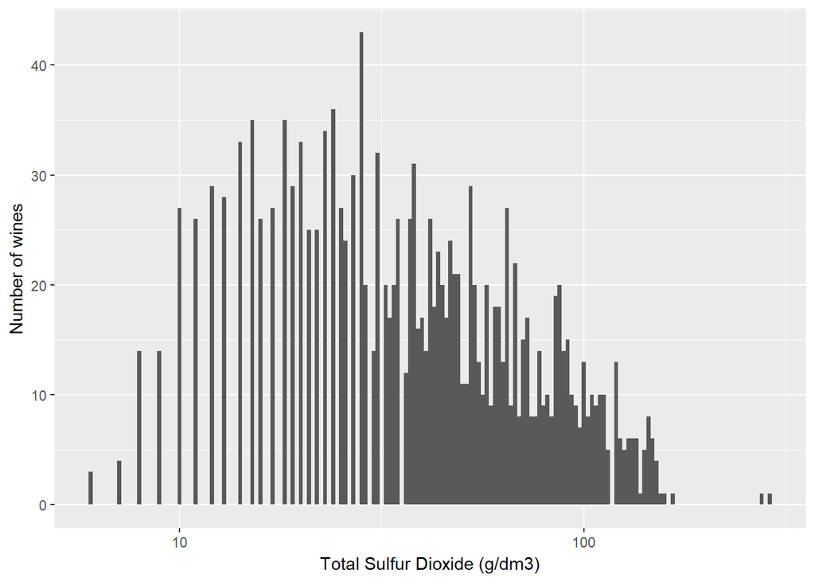

```
##    Min. 1st Qu.  Median    Mean 3rd Qu.    Max.
##    6.00   22.00   38.00   46.47   62.00  289.00
```

> Total sulfur dioxide is the total amount of free and bound sulfure dioxide. The mean amount of sulfur dioxide is 46.47mg/dm^3 The sample level range between 6mg/dm^3 to 289mg/dm^3 We can see indeed some outliers up to 289mg/dm^3 which is extremely high level of sulfur dioxide even over legal limits. The distribution is skewed to the right.

# Proportion of free sulfur dioxide

> It can be interesting to check the proportion of free sulfur on total sulfur dioxide. A higher proportion of free sulfur dioxide is considered better as the wine will be more stable with more antioxydant.

```
##   X fixed.acidity volatile.acidity citric.acid residual.sugar chlorides
## 1 1           7.4             0.70        0.00            1.9     0.076
## 2 2           7.8             0.88        0.00            2.6     0.098
## 3 3           7.8             0.76        0.04            2.3     0.092
## 4 4          11.2             0.28        0.56            1.9     0.075
## 5 5           7.4             0.70        0.00            1.9     0.076
## 6 6           7.4             0.66        0.00            1.8     0.075
##   free.sulfur.dioxide total.sulfur.dioxide density   pH sulphates alcohol
## 1                  11                   34  0.9978 3.51      0.56     9.4
## 2                  25                   67  0.9968 3.20      0.68     9.8
## 3                  15                   54  0.9970 3.26      0.65     9.8
## 4                  17                   60  0.9980 3.16      0.58     9.8
## 5                  11                   34  0.9978 3.51      0.56     9.4
## 6                  13                   40  0.9978 3.51      0.56     9.4
##   quality proportion.free.sulfur.dioxide
## 1       5                      0.3235294
## 2       5                      0.3731343
## 3       5                      0.2777778
## 4       6                      0.2833333
## 5       5                      0.3235294
## 6       5                      0.3250000
```

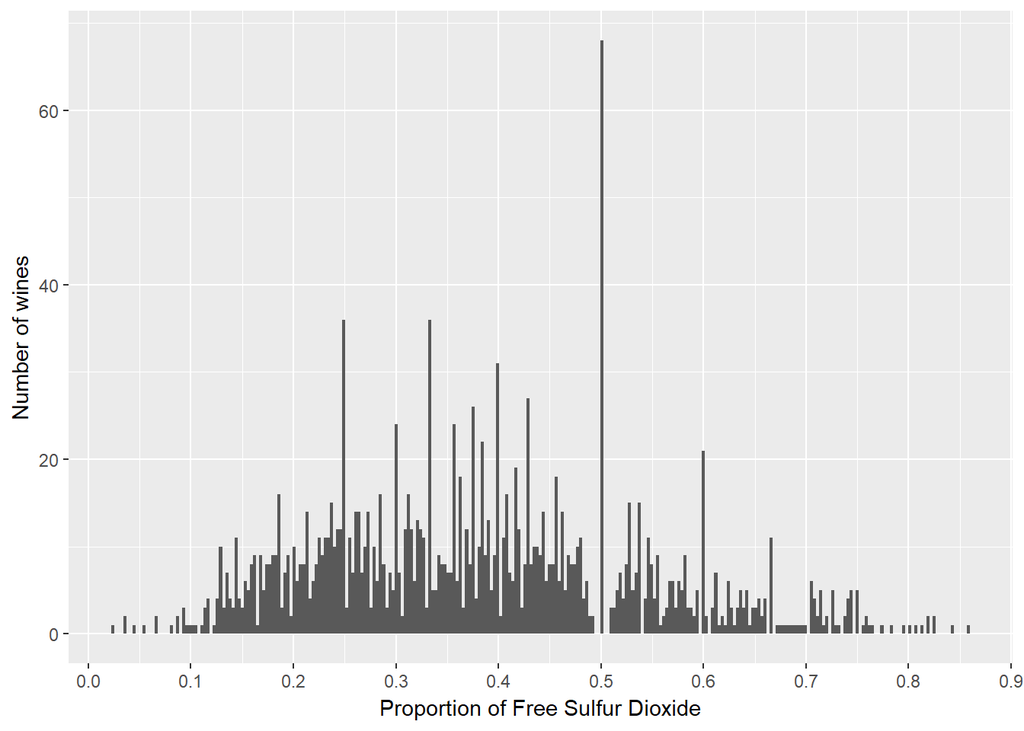

```
##    Min. 1st Qu.  Median    Mean 3rd Qu.    Max.
## 0.02273 0.25926 0.37500 0.38231 0.48485 0.85714
```

# Density

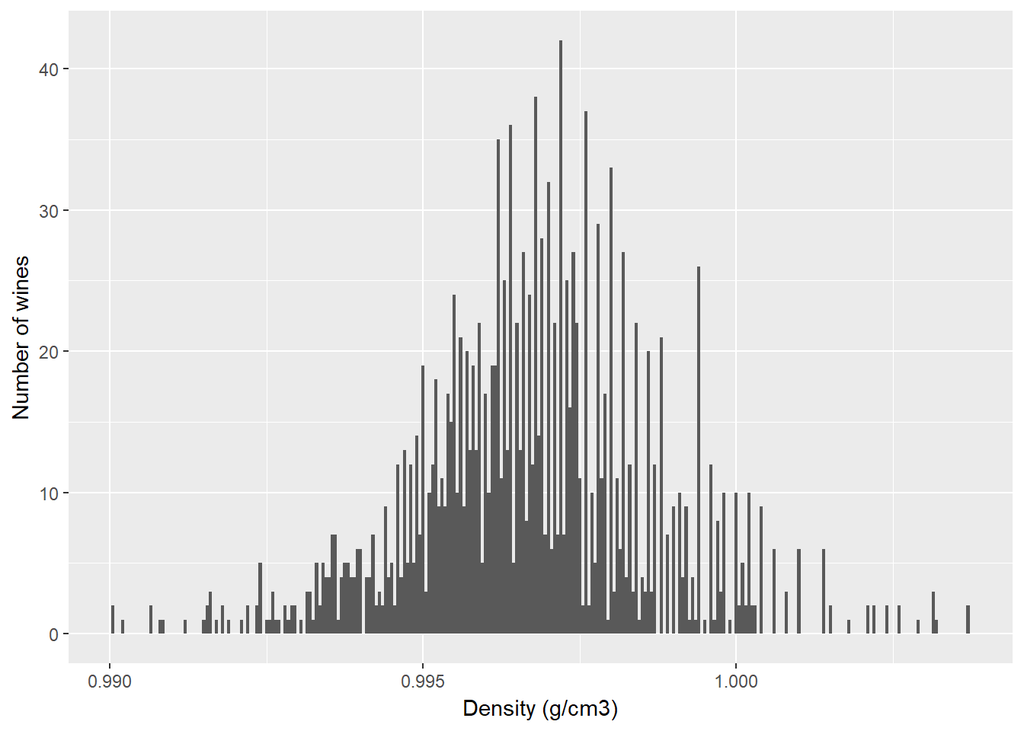

```
##    Min. 1st Qu.  Median    Mean 3rd Qu.    Max.
##  0.9901  0.9956  0.9968  0.9967  0.9978  1.0037
```

> Wine density is very close to water density The sample’s density range from 0.9901g/cm^3 to 1.0037g/cm^3 The mean is around 0.9967g/cm^3 The distribution seems to be almost normally distributed with median close to mean

# pH

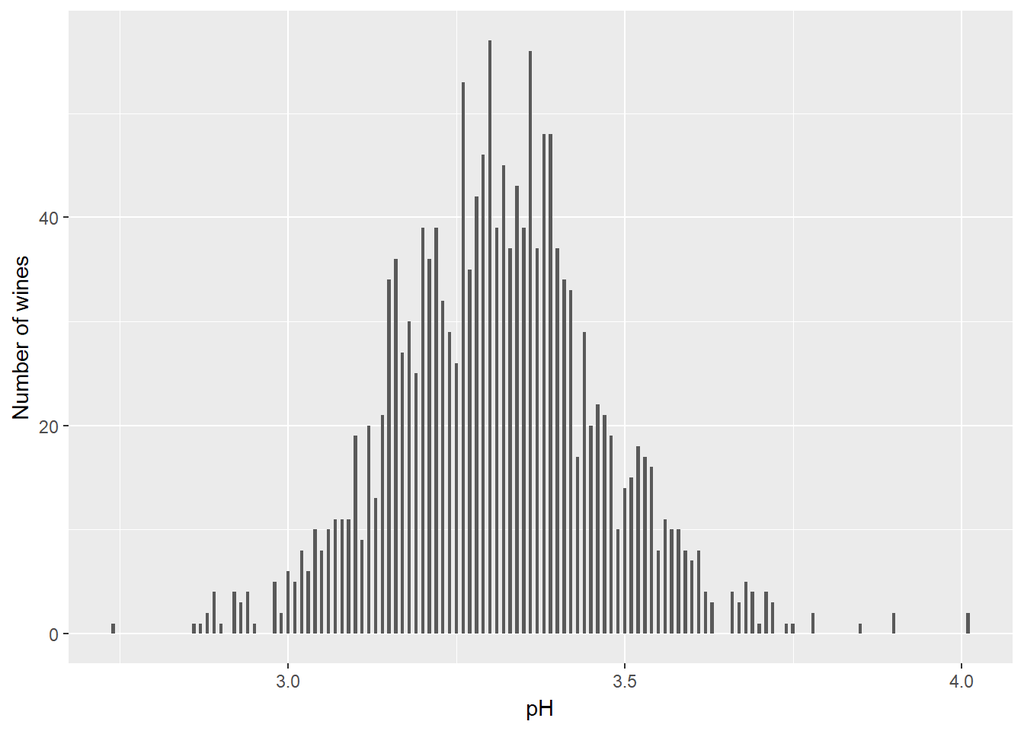

```
##    Min. 1st Qu.  Median    Mean 3rd Qu.    Max.
##   2.740   3.210   3.310   3.311   3.400   4.010
```

# Sulphates

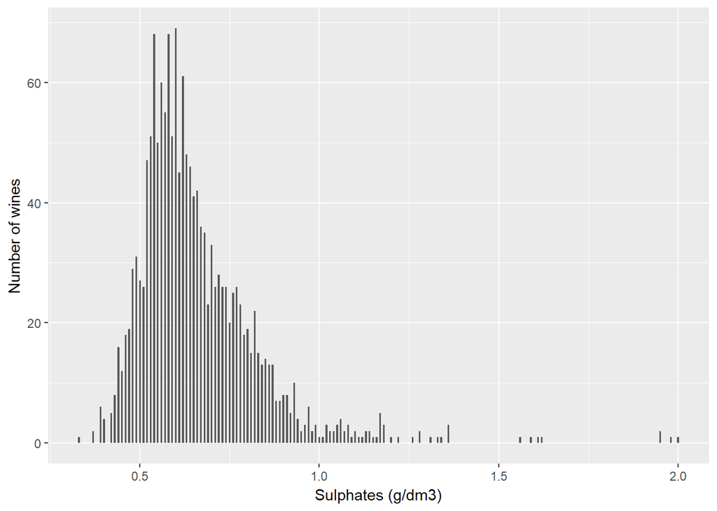

```
##    Min. 1st Qu.  Median    Mean 3rd Qu.    Max.
##  0.3300  0.5500  0.6200  0.6581  0.7300  2.0000
```

> The sample’s sulfate range from 0.33g/dm^3 to 2g/dm^3 The mean is around 0.6581g/dm^3 The distribution is skewed to the right

# Alcohol

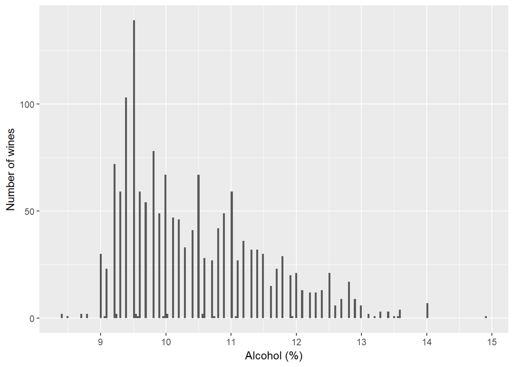

```
##    Min. 1st Qu.  Median    Mean 3rd Qu.    Max.
##    8.40    9.50   10.20   10.42   11.10   14.90
```

> The sample’s alcohol range from 8.4% to 14.9% The mean is around 10.42% The distribution is skewed to the right

# Univariate Analysis

### What is the structure of your dataset?

There is 1599 red wines tested in this dataset with 12 features ( fixed acidity, volatile aciditu, citric acidity, residual sugar, chlorides, free and total sulfure dioxide, density, pH, sulphate, alcohol and quality). The first 11 features are continuous numeric data. Only the quality is a discrete date ranging from 1 to 10.

> Most of the red wines quality is ranked between 5 and 6. The mean fixed acidity level is at 8.32g/dm^3 The mean volatile acidity level is at 0.5278g/dm^3 For citric acid, it is interesting to notice that there are contain some pics at around 0, 0.25, 0.5g/dm^3 75% of the wines have residual sugar lower than 2.6g/dm^3 and are rather dry wines 75% pf the wines have chlorides lower than 0.09g/dm^3 For the sulfur dioxide and sulfate level, the data are slightly more dispersed which mean this might be a criteria of differentiation for the wines quality. The mean density is at 0.9967g/cm^3 quite similar to water The pH is almost normally distributed ranging from 2.74 to 4.01 which is a relatively normal range for red wines The sample’s alcohol range from 8.4% to 14.9%

### What is/are the main feature(s) of interest in your dataset?

The main features of interest are the acidity (fixed, volatile, citric acid) and the sulfur content (volatile, total, sulfate added) and alcohol that might have a significative impact on the quality of the wine.

### What other features in the dataset do you think will help support your investigation into your feature(s) of interest?

The other features such as residual sugar, chlorides, pH, density would also support my investigations since there are important criteria to judge the wines though the dataset seems rather homogeneous here

### Did you create any new variables from existing variables in the dataset?

I calculated the proportion of free sulfur dioxide on total as it is also a criteria of quality for the wines. The higher the proportion of free sulfur dioxide the more antioxydant content the wine have and will keep the wine better.

### Of the features you investigated, were there any unusual distributions? Did you perform any operations on the data to tidy, adjust, or change the form of the data? If so, why did you do this?

I mostly adjusted the binwidth in the different charts to better perceive the trend. Free sulfur dioxide and total sulfure dioxide were rather right skewed so i log-transformed these charts.

# Bivariate Plots Section

## Correlation matrix including p-value for correlation significance

```
##                                    X fixed.acidity volatile.acidity
## X                               1.00         -0.27            -0.01
## fixed.acidity                  -0.27          1.00            -0.26
## volatile.acidity               -0.01         -0.26             1.00
## citric.acid                    -0.15          0.67            -0.55
## residual.sugar                 -0.03          0.11             0.00
## chlorides                      -0.12          0.09             0.06
## free.sulfur.dioxide             0.09         -0.15            -0.01
## total.sulfur.dioxide           -0.12         -0.11             0.08
## density                        -0.37          0.67             0.02
## pH                              0.14         -0.68             0.23
## sulphates                      -0.13          0.18            -0.26
## alcohol                         0.25         -0.06            -0.20
## quality                         0.07          0.12            -0.39
## proportion.free.sulfur.dioxide  0.34         -0.13            -0.07
##                                citric.acid residual.sugar chlorides
## X                                    -0.15          -0.03     -0.12
## fixed.acidity                         0.67           0.11      0.09
## volatile.acidity                     -0.55           0.00      0.06
## citric.acid                           1.00           0.14      0.20
## residual.sugar                        0.14           1.00      0.06
## chlorides                             0.20           0.06      1.00
## free.sulfur.dioxide                  -0.06           0.19      0.01
## total.sulfur.dioxide                  0.04           0.20      0.05
## density                               0.36           0.36      0.20
## pH                                   -0.54          -0.09     -0.27
## sulphates                             0.31           0.01      0.37
## alcohol                               0.11           0.04     -0.22
## quality                               0.23           0.01     -0.13
## proportion.free.sulfur.dioxide       -0.17          -0.07     -0.11
##                                free.sulfur.dioxide total.sulfur.dioxide
## X                                             0.09                -0.12
## fixed.acidity                                -0.15                -0.11
## volatile.acidity                             -0.01                 0.08
## citric.acid                                  -0.06                 0.04
## residual.sugar                                0.19                 0.20
## chlorides                                     0.01                 0.05
## free.sulfur.dioxide                           1.00                 0.67
## total.sulfur.dioxide                          0.67                 1.00
## density                                      -0.02                 0.07
```

[output cut: 100 more lines]

```
##                                proportion.free.sulfur.dioxide
## X                              0.0000
## fixed.acidity                  0.0000
## volatile.acidity               0.0037
## citric.acid                    0.0000
## residual.sugar                 0.0047
## chlorides                      0.0000
## free.sulfur.dioxide            0.0000
## total.sulfur.dioxide           0.0000
## density                        0.0000
## pH                             0.0000
## sulphates                      0.6760
## alcohol                        0.0000
## quality                        0.0000
## proportion.free.sulfur.dioxide
```

## Correlation chart

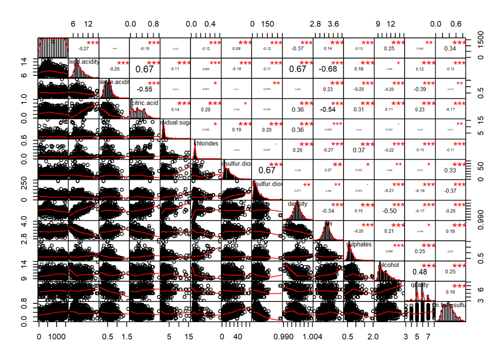

> Looking at the correlation matrix, it seems that alcohol, sulfates, citric acid and proportion of free sulfur dioxid have a positive correlation with the wine quality. While interestingly, total and free sulfur dioxide have a negative correlation with wine quality Another important factor is the volatile acidity which is negatively correlated with wine quality

> Therefore, we are going to further analyse the impact of alcohol, volatile acidity, citric acid, sulfates and sulfur dioxide content on the wine quality.  
> One factor might influence another. There is a strong correlation between citric acid, sulfates and acidity I would have expected a correlation between sulfates and sulfur dioxide content since both act as an antimicrobial and antioxidant in the wine, but it is not the case.

> Finally, it is notable that residual sugar have the lowest correlation with the wine here, the correlation p-value is not even significant. In fact, the residual sugar level is quite homogeneous in this dataset as we have seen in the univariate, most of the wines are dry, which might explain the low correlation here with the wine quality.

# Analysis between alcohol and quality

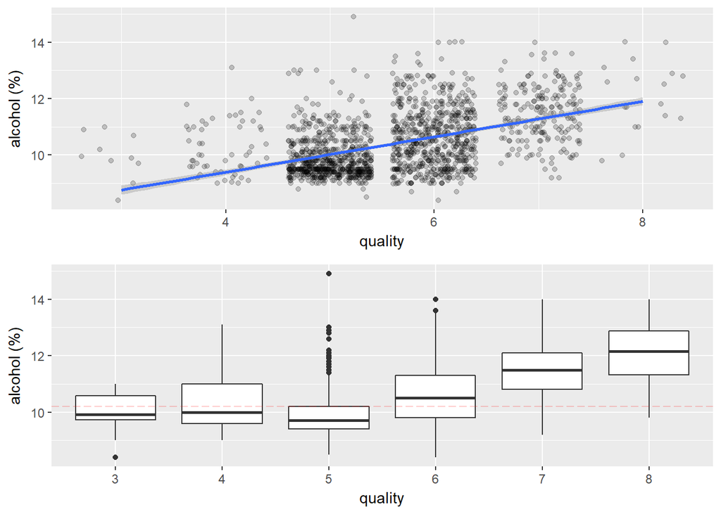

```
## xvar: 3
##    Min. 1st Qu.  Median    Mean 3rd Qu.    Max.
##   8.400   9.725   9.925   9.955  10.575  11.000
## --------------------------------------------------------
## xvar: 4
##    Min. 1st Qu.  Median    Mean 3rd Qu.    Max.
##    9.00    9.60   10.00   10.27   11.00   13.10
## --------------------------------------------------------
## xvar: 5
##    Min. 1st Qu.  Median    Mean 3rd Qu.    Max.
##     8.5     9.4     9.7     9.9    10.2    14.9
## --------------------------------------------------------
## xvar: 6
##    Min. 1st Qu.  Median    Mean 3rd Qu.    Max.
##    8.40    9.80   10.50   10.63   11.30   14.00
## --------------------------------------------------------
## xvar: 7
##    Min. 1st Qu.  Median    Mean 3rd Qu.    Max.
##    9.20   10.80   11.50   11.47   12.10   14.00
## --------------------------------------------------------
## xvar: 8
##    Min. 1st Qu.  Median    Mean 3rd Qu.    Max.
##    9.80   11.32   12.15   12.09   12.88   14.00
```

> We can see a positive correlation between quality and alcohol level Reds wines rated above 6 have a alcohol median higher than the median of the sample It is also notable that there are more outliers for red wines rated 5, the third quartile is lower than the mean sample.

```
##
## Call:
## lm(formula = xvar ~ yvar, data = datareds)
##
## Coefficients:
## (Intercept)         yvar
##      1.8750       0.3608
```

```
##
## Call:
## lm(formula = xvar ~ yvar, data = datareds)
##
## Residuals:
##     Min      1Q  Median      3Q     Max
## -2.8442 -0.4112 -0.1690  0.5166  2.5888
##
## Coefficients:
##             Estimate Std. Error t value Pr(>|t|)
## (Intercept)  1.87497    0.17471   10.73   <2e-16 ***
## yvar         0.36084    0.01668   21.64   <2e-16 ***
## ---
## Signif. codes:  0 '***' 0.001 '**' 0.01 '*' 0.05 '.' 0.1 ' ' 1
##
## Residual standard error: 0.7104 on 1597 degrees of freedom
## Multiple R-squared:  0.2267, Adjusted R-squared:  0.2263
## F-statistic: 468.3 on 1 and 1597 DF,  p-value: < 2.2e-16
```

> When looking at R-squared of the linear regression, it seems that alcohol explains 22.7% of the quality variance.

# Analysis between citric acid, volatile acidity and quality

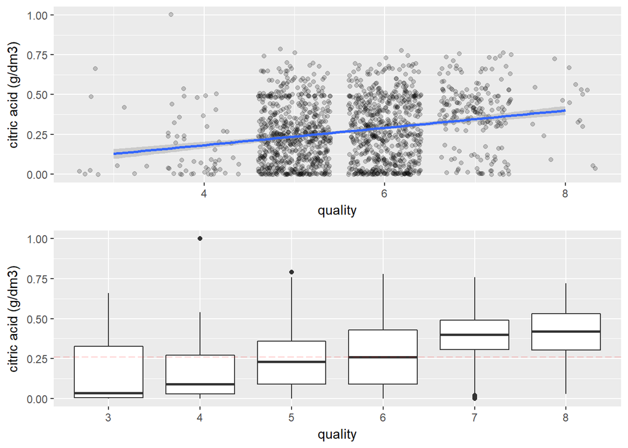

```
## xvar: 3
##    Min. 1st Qu.  Median    Mean 3rd Qu.    Max.
##  0.0000  0.0050  0.0350  0.1710  0.3275  0.6600
## --------------------------------------------------------
## xvar: 4
##    Min. 1st Qu.  Median    Mean 3rd Qu.    Max.
##  0.0000  0.0300  0.0900  0.1742  0.2700  1.0000
## --------------------------------------------------------
## xvar: 5
##    Min. 1st Qu.  Median    Mean 3rd Qu.    Max.
##  0.0000  0.0900  0.2300  0.2437  0.3600  0.7900
## --------------------------------------------------------
## xvar: 6
##    Min. 1st Qu.  Median    Mean 3rd Qu.    Max.
##  0.0000  0.0900  0.2600  0.2738  0.4300  0.7800
## --------------------------------------------------------
## xvar: 7
##    Min. 1st Qu.  Median    Mean 3rd Qu.    Max.
##  0.0000  0.3050  0.4000  0.3752  0.4900  0.7600
## --------------------------------------------------------
## xvar: 8
##    Min. 1st Qu.  Median    Mean 3rd Qu.    Max.
##  0.0300  0.3025  0.4200  0.3911  0.5300  0.7200
```

> There is also a positive correlation between citric acid and quality Citric acid is a naturally present in grape and can also be an additive to correct the pH of the wine We can see here that red wines rated above 6 have a higher citric acid median than the sample. while almost 75% of wines rated 3 and 4 are below the median citric acid level of the sample.

```
##
## Call:
## lm(formula = xvar ~ yvar, data = datareds)
##
## Coefficients:
## (Intercept)         yvar
##      5.3817       0.9385
```

```
##
## Call:
## lm(formula = xvar ~ yvar, data = datareds)
##
## Residuals:
##     Min      1Q  Median      3Q     Max
## -3.0011 -0.5976  0.1021  0.5057  2.5901
##
## Coefficients:
##             Estimate Std. Error t value Pr(>|t|)
## (Intercept)  5.38172    0.03372 159.610   <2e-16 ***
## yvar         0.93845    0.10104   9.288   <2e-16 ***
## ---
## Signif. codes:  0 '***' 0.001 '**' 0.01 '*' 0.05 '.' 0.1 ' ' 1
##
## Residual standard error: 0.7869 on 1597 degrees of freedom
## Multiple R-squared:  0.05124,    Adjusted R-squared:  0.05065
## F-statistic: 86.26 on 1 and 1597 DF,  p-value: < 2.2e-16
```

> Based on the R-squared of the linear regression, citric acid explain only 5% of the quality variance. However, we can see from above correlation matrix, there is a strong correlation between citric acid, pH, fixed and volatile acidity.

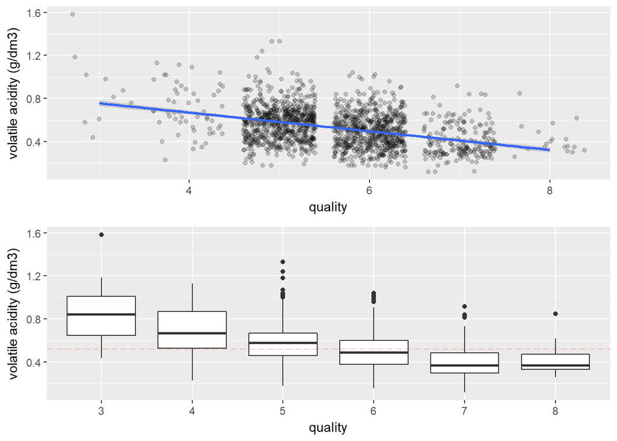

```
## xvar: 3
##    Min. 1st Qu.  Median    Mean 3rd Qu.    Max.
##  0.4400  0.6475  0.8450  0.8845  1.0100  1.5800
## --------------------------------------------------------
## xvar: 4
##    Min. 1st Qu.  Median    Mean 3rd Qu.    Max.
##   0.230   0.530   0.670   0.694   0.870   1.130
## --------------------------------------------------------
## xvar: 5
##    Min. 1st Qu.  Median    Mean 3rd Qu.    Max.
##   0.180   0.460   0.580   0.577   0.670   1.330
## --------------------------------------------------------
## xvar: 6
##    Min. 1st Qu.  Median    Mean 3rd Qu.    Max.
##  0.1600  0.3800  0.4900  0.4975  0.6000  1.0400
## --------------------------------------------------------
## xvar: 7
##    Min. 1st Qu.  Median    Mean 3rd Qu.    Max.
##  0.1200  0.3000  0.3700  0.4039  0.4850  0.9150
## --------------------------------------------------------
## xvar: 8
##    Min. 1st Qu.  Median    Mean 3rd Qu.    Max.
##  0.2600  0.3350  0.3700  0.4233  0.4725  0.8500
```

> The presence of volatile acidity also impact the wine quality but the correlation here is negative In fact, higher presence of volatile acidity means that the wine is turning into vinegar Red wines rated above 6 have a median volatile acidity lower than the sample median More than 75% of red wines rated 3 and 4 have a volatile acidity higher than the sample median

```
##
## Call:
## lm(formula = xvar ~ yvar, data = datareds)
##
## Coefficients:
## (Intercept)         yvar
##       6.566       -1.761
```

```
##
## Call:
## lm(formula = xvar ~ yvar, data = datareds)
##
## Residuals:
##      Min       1Q   Median       3Q      Max
## -2.79071 -0.54411 -0.00687  0.47350  2.93148
##
## Coefficients:
##             Estimate Std. Error t value Pr(>|t|)
## (Intercept)  6.56575    0.05791  113.39   <2e-16 ***
## yvar        -1.76144    0.10389  -16.95   <2e-16 ***
## ---
## Signif. codes:  0 '***' 0.001 '**' 0.01 '*' 0.05 '.' 0.1 ' ' 1
##
## Residual standard error: 0.7437 on 1597 degrees of freedom
## Multiple R-squared:  0.1525, Adjusted R-squared:  0.152
## F-statistic: 287.4 on 1 and 1597 DF,  p-value: < 2.2e-16
```

> Based on the R-squared of the linear regression, volatile acidity seems to explain 15% of the quality variance

> Acidity is good in wine, especially citric acidity gives a sensation of freshness But volatile acidity negatively impact the wine quality. We see also that pH is positively correlated with volatile acidity and negatively correlated with citric acid and quality. Though the correlation with the latter is very low.

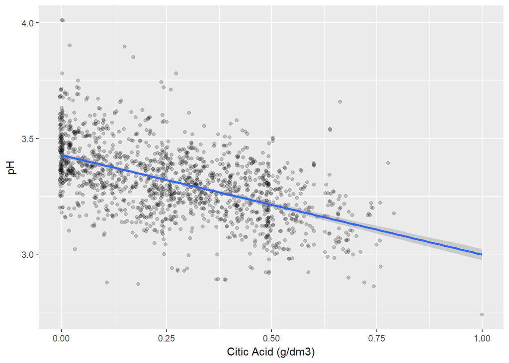

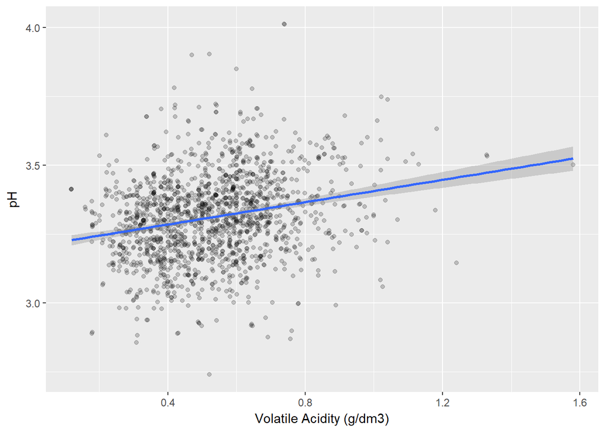

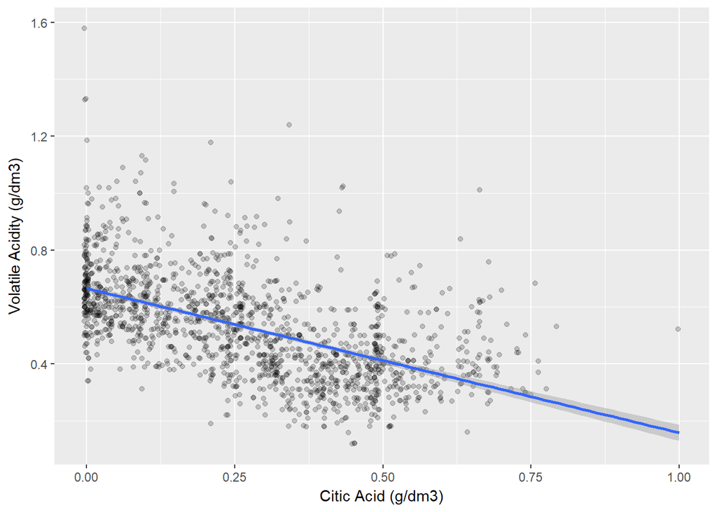

> We plot above charts to see the relation between pH, citric acid and volatile acidity. It seems that citric acid is used to correct the pH to give more freshness to the wine But wines with low citric acid have more volatile acidity and seems to drive the pH on the higher end Nevertheless, since pH have low correlation with the wine quality as it is in the “normal” average range for red wines, we might think that pH is a measure that winemakers have a target range but it is the type of acidity that make the difference for the tasting.

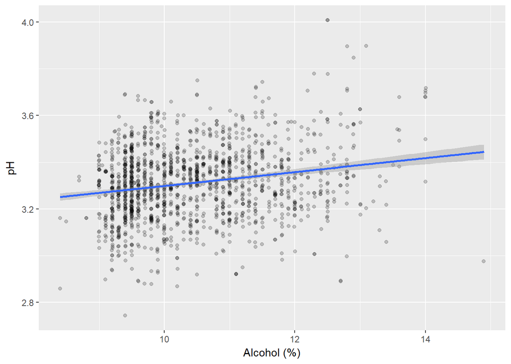

> We saw a positive correlation between alcohol and pH at 0.2, but when we plot the chart it is difficult to draw any conclusion from that.

# Analysis between sulfates and quality

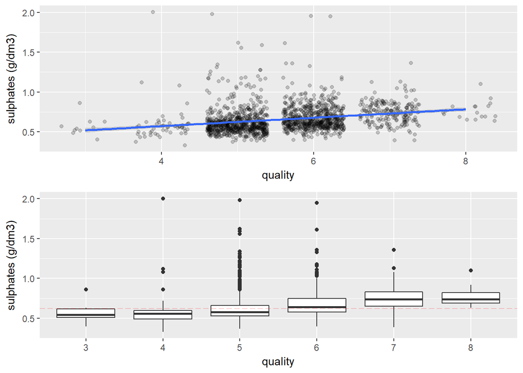

```
## xvar: 3
##    Min. 1st Qu.  Median    Mean 3rd Qu.    Max.
##  0.4000  0.5125  0.5450  0.5700  0.6150  0.8600
## --------------------------------------------------------
## xvar: 4
##    Min. 1st Qu.  Median    Mean 3rd Qu.    Max.
##  0.3300  0.4900  0.5600  0.5964  0.6000  2.0000
## --------------------------------------------------------
## xvar: 5
##    Min. 1st Qu.  Median    Mean 3rd Qu.    Max.
##   0.370   0.530   0.580   0.621   0.660   1.980
## --------------------------------------------------------
## xvar: 6
##    Min. 1st Qu.  Median    Mean 3rd Qu.    Max.
##  0.4000  0.5800  0.6400  0.6753  0.7500  1.9500
## --------------------------------------------------------
## xvar: 7
##    Min. 1st Qu.  Median    Mean 3rd Qu.    Max.
##  0.3900  0.6500  0.7400  0.7413  0.8300  1.3600
## --------------------------------------------------------
## xvar: 8
##    Min. 1st Qu.  Median    Mean 3rd Qu.    Max.
##  0.6300  0.6900  0.7400  0.7678  0.8200  1.1000
```

> The presence of sulphates in wines is generally negatively perceived. (wondering if there is an typo error between sulphates and sulfites. Normally sulphates should not be involved in the wine making. But for the exercise, we will continue to use the term sulphates) It is an additif used to better preserve the wines. We see here that there is a positive correlation between sulphates and wine quality. More than 75% of wines rated above 6 have a sulphate content higher than the sample median.

```
##
## Call:
## lm(formula = xvar ~ yvar, data = datareds)
##
## Coefficients:
## (Intercept)         yvar
##       4.848        1.198
```

```
##
## Call:
## lm(formula = xvar ~ yvar, data = datareds)
##
## Residuals:
##     Min      1Q  Median      3Q     Max
## -3.2432 -0.5424  0.1102  0.4456  2.3977
##
## Coefficients:
##             Estimate Std. Error t value Pr(>|t|)
## (Intercept)  4.84775    0.07842   61.82   <2e-16 ***
## yvar         1.19771    0.11539   10.38   <2e-16 ***
## ---
## Signif. codes:  0 '***' 0.001 '**' 0.01 '*' 0.05 '.' 0.1 ' ' 1
##
## Residual standard error: 0.7819 on 1597 degrees of freedom
## Multiple R-squared:  0.0632, Adjusted R-squared:  0.06261
## F-statistic: 107.7 on 1 and 1597 DF,  p-value: < 2.2e-16
```

> Looking at the R-squared of the linear regression, sulphates seem to explain 6% of the quality variance. But interestingly, wine quality is negatively correlated with the free and total sulfure dioxide and the correlation of sulphates with the latters is positive but very low.

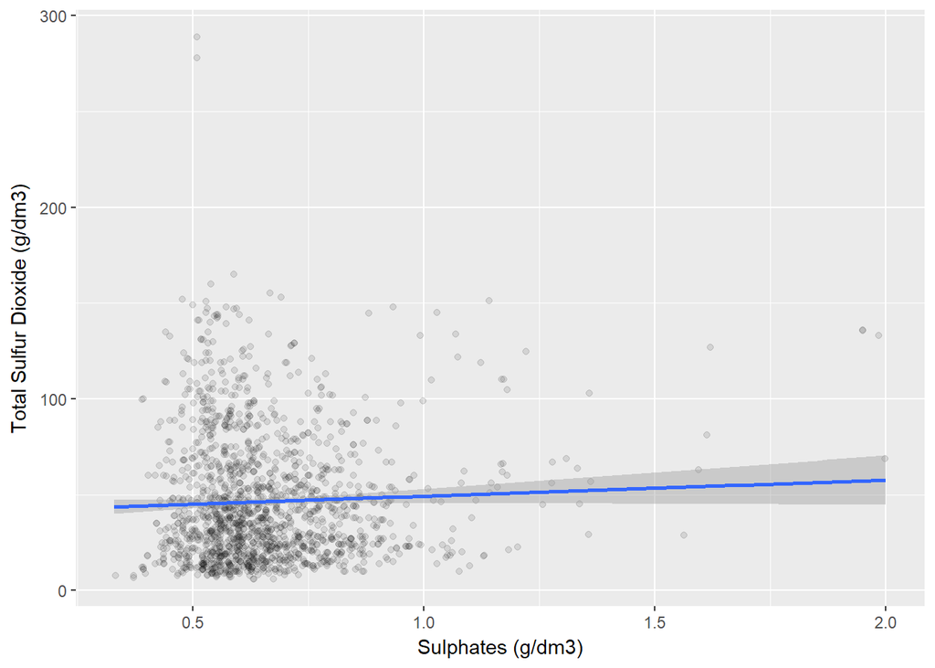

> It can be that sulphates help to preserve the quality of the wines but without impacting to much the levels of sulfur dioxide. Nevertheless, based on quick search online, we did not see any material on sulphates and wine.